# Paired Sentinel-2 reflectance differences

CTR-54 investigation · CTR-55 geospatial and CTR-56 statistical delivery · draft for review

Author

Roger Tomlinson and Thomas Bayes · Ctrl+Sea

Published

October 20, 2026

## 0.1 Take-home message: temporal comparison

ACOLITE generally gives lower surface reflectance than Sen2Cor across the 22 matched acquisitions. The date-to-date disagreement is much larger than the change in the fitted median curves. Restricting the comparison to pixels observed on every date produces similar curves, but individual acquisitions and missing quality information materially affect the temporal smooths. These are descriptive comparisons of processing methods, not evidence of atmospheric-correction accuracy or ecological change.

## 0.2 Meaningful results

The median across the 22 **date-level spatial medians** is −0.00962, −0.00924, −0.00751 and −0.00935 for B2, B3, B4 and B8, respectively. These quantities differ from the spatial median of pixel-level temporal medians in the geospatial report. Date-level spatial medians are negative on 19/22 dates for each visible band and 21/22 for B8. Spatial sample SD ranges from about 0.0043 to 0.0291 across all band/date combinations; it measures within-date spatial heterogeneity of disagreement, not uncertainty in the spatial median.

The median GAM smooths reduce to almost straight lines (effective degrees of freedom approximately 1), with fitted endpoint increases of 0.0056–0.0074 reflectance units. The working-model uncertainty intervals include zero for all four increases. The SD smooths have effective degrees of freedom 1.40–2.72. Broad mid-2025 elevations in the visible-band SD curves should not be interpreted as a validated seasonal cycle.

## 0.3 Issues and limitations

Only 22 irregularly spaced acquisitions cover 6 January 2025–27 March 2026. Gaps range from 2 to 70 days; the June–August and December–March gaps are 60 and 70 days. Sensors are unevenly represented (S2A: 3; S2B: 11; S2C: 8), and sensor, acquisition date, atmospheric conditions, tide and quality information cannot be disentangled by these curves. Both March 2026 dates lack supplied ACOLITE flags. Removing them changes fitted SD curves by up to 0.00579 over the remaining date range. This sensitivity changes both quality availability and time support; it does not identify a causal effect of missing flags.

The median-model residuals have a pronounced negative tail, and the SD-model residuals show negative correlation between adjacent acquisitions. The displayed uncertainty bands use a working independent Gaussian model and are **illustrative, approximate pointwise model intervals**, not validated frequentist coverage guarantees, simultaneous bands, prediction intervals, or uncertainty from spatial sampling. No temporal significance claim is made.

## 0.4 Implications and next steps

Use the figure to describe the magnitude and acquisition-specific variability of disagreement. Coverage sensitivity supports the conclusion that changing spatial coverage is not the only source of this variability; it does not prove that coverage or quality selection is ignorable. Rachel can incorporate these qualified results into the investigation report. Independent scientific review under CTR-59 and authenticated PI scientific approval remain pending. Manuscript integration, merge and publication are separate and unauthorized.

## 0.5 Research question, data and study area

How do the per-date spatial median and sample SD of paired surface-reflectance differences vary through time, separately for B2/B3/B4/B8? Define ΔR = ACOLITE − Sen2Cor in dimensionless surface-reflectance units; B8 is the broad near-infrared band, not B8A. Positive ΔR means higher ACOLITE reflectance.

This statistical extension consumes CTR-55 scientific revision `1bbb23b3b94e775a60aa921f8c9c4f86f51926cb` and handoff revision `1631082`, without repeating atmospheric correction or raster production. It uses `tables/date_band_summary.csv`, whose unique key is `(pair_id, band, domain)`. The 528 rows are 22 dates × four bands × six overlapping domains, not 528 temporal replicates. Each model has 22 equally weighted acquisition-level summaries; bands are fitted separately. No pixel counts, spatial SDs or domains are used as independent temporal replication or precision weights.

The supplied T28QCH crop contains 7,428,162 10-m cells (742.8162 km²) in EPSG:32628, covering land, intertidal and water. It is not a marine-only sample. Primary coverage varies approximately 72–98% of that fixed grid. Source pairing, reflectance scale/offset handling, quality masks, retained negative reflectances and exact encoded-fill exclusions are documented in the preserved CTR-55 methods. The geospatial table contract is preserved in `TABLE_CONTRACT.md`.

## 0.6 Statistical methods

For band *b* and acquisition *i*, let *M* be the median and *S* the sample SD (denominator number of valid pixels minus one) of paired pixel ΔR. Fit separate working Gaussian additive models:

[ M_{ib}=*{b,M}+f*{b,M}(t_i)+*{ib,M}, S*{ib}=*{b,S}+f*{b,S}(t_i)+_{ib,S}. ]

Here *t* is elapsed days since 6 January 2025. Each smooth is a penalized cubic regression spline (`mgcv::gam`, `bs="cr"`, `k=5`), with smoothing selected by restricted maximum likelihood (REML). The main fits have at most four smooth degrees of freedom plus an intercept. This modest basis allows broad curvature without attempting to resolve seasonal structure from roughly 15 months of sparse data. It is checked against `k=10`, rather than selected to obtain an appealing curve. All date observations remain in the primary fits; none are removed as outliers. There are no zero or missing SDs, so logarithms need neither a pseudocount nor exclusions.

Exponentiating the fitted log-SD gives the fitted **conditional median of date-level spatial SD** under the working lognormal model (also the exponential of the fitted mean log-SD). It is not an arithmetic conditional mean; no `exp(sigma²/2)` correction is applied. All plotted SD points remain on their original reflectance scale. Predictions use 401 evenly spaced elapsed-day values within observed bounds only. Interpolation across long gaps is weakly supported; there is no extrapolation. Refit comparisons after omitting dates use only the overlapping temporal support.

We use `predict.gam(..., unconditional=TRUE)` for approximate coefficient uncertainty including smoothing-parameter uncertainty, available for all eight primary models. Pointwise intervals are linear predictor ±1.96 SE, exponentiated for SD. Endpoint median differences and SD ratios use the full covariance of the difference of the endpoint design rows, rather than adding independent endpoint errors. These working-model summaries quantify uncertainty conditional on the observed acquisition selection; model misspecification and sensor/quality confounding limit their interpretation.

Basis assessment uses a reproducible 1,000-permutation `k.check` (seed 56054), effective degrees of freedom and response-scale changes after doubling the basis. Residual checks include standardized residuals through time, normal quantile plots, residual spread versus fitted values, ordered adjacent residual correlation, and an empirical semivariogram using actual elapsed-day lags. The ordered correlation is an acquisition-lag diagnostic, **not** a one-day autocorrelation. With only 22 irregular observations, neither this diagnostic nor a nonsignificant basis test establishes independence or correct distributional assumptions. We retain the descriptive models rather than claim a reliably identified temporal covariance model.

Influence is assessed by 22 leave-one-acquisition-out refits per primary model. Spatial-domain sensitivity refits all eight models for each of five alternative domains: complete-date core, ≥18/22-date core, common pre-quality footprint, inclusion of SCL class 7, and exclusion of high-TOA flags. The complete-date core is the principal comparable-domain check because exactly the same pixels enter each date within a band. The ≥18-date core and pre-quality footprint still have date-specific missing values after quality filtering. These are overlapping conditional subsets, not independent replication. Spearman correlations of coverage with observations and model residuals are descriptive checks, not causal adjustment.

Methodological implementation follows the primary [mgcv basis-dimension guidance](https://www.stat.ethz.ch/R-manual/R-devel/library/mgcv/html/choose.k.html), [GAM diagnostic documentation](https://www.stat.ethz.ch/R-manual/R-devel/library/mgcv/html/gam.check.html), and [prediction documentation](https://www.stat.ethz.ch/R-manual/R-devel/library/mgcv/html/predict.gam.html), consulted 20 October 2026. Installed implementation: R 4.3.3 and mgcv 1.9-1; the full session record is supplied.

## 0.7 Temporal figure and observed estimates

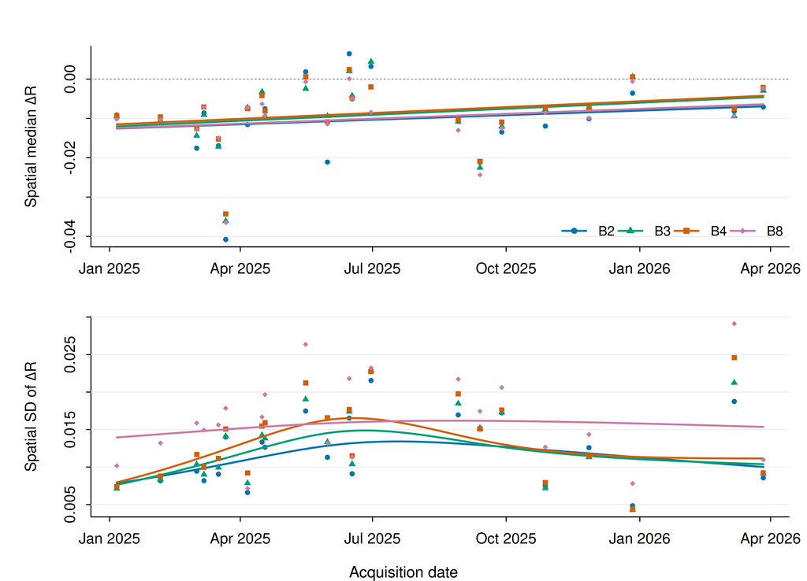

Figure 1: Date-level differences between atmospheric corrections. Points show all 22 spatial medians (top) and sample SDs (bottom) per band; lines are separate descriptive REML GAMs. ΔR = ACOLITE − Sen2Cor, dimensionless reflectance. SD curves are exponentiated log-scale fits. Curves span observed dates only; the two March 2026 acquisitions lack ACOLITE flags.

Unweighted summaries across 22 observed dates; median_across_dates is not a pooled-pixel statistic.

| band | statistic | n_dates | min | max | median_across_dates | n_negative |
| --- | --- | --- | --- | --- | --- | --- |
| B2 | median_delta | 22 | -0.04078 | 0.00645 | -0.00962 | 19 |
| B2 | sd_delta | 22 | 0.00484 | 0.02154 | 0.01194 | 0 |
| B3 | median_delta | 22 | -0.03608 | 0.00441 | -0.00924 | 19 |
| B3 | sd_delta | 22 | 0.00434 | 0.02283 | 0.01233 | 0 |
| B4 | median_delta | 22 | -0.03431 | 0.00247 | -0.00751 | 19 |
| B4 | sd_delta | 22 | 0.00437 | 0.02458 | 0.01337 | 0 |
| B8 | median_delta | 22 | -0.03648 | 0.00009 | -0.00935 | 21 |
| B8 | sd_delta | 22 | 0.00714 | 0.02911 | 0.01574 | 0 |

## 0.8 Coverage, influence and diagnostic findings

The fixed complete-date core contains 3,541,100–3,541,623 pixels per band (approximately 47.7% of the grid). Primary versus complete-core date summaries correlate 0.9936–0.9970 for medians and 0.9964–0.9985 for SDs. The maximum primary-to-core curve shift is 0.00103 for medians and 0.000786 for SDs. A high correlation does not exclude a consistent level shift: for example, B2 spatial medians shift upward by a median 0.000966 in the core. This consistently clear subset can differ ecologically from excluded pixels.

Fixed complete-date core versus primary domain, in reflectance units.

|  | band | statistic | min_pixels | observed_median_change | observed_max_change | curve_max_change |
| --- | --- | --- | --- | --- | --- | --- |
| 3 | B2 | median_delta | 3541502 | 0.000966 | 0.002863 | 0.001031 |
| 8 | B2 | sd_delta | 3541502 | 0.000615 | 0.001979 | 0.000780 |
| 13 | B3 | median_delta | 3541623 | 0.000701 | 0.002488 | 0.000800 |
| 18 | B3 | sd_delta | 3541623 | 0.000574 | 0.001882 | 0.000786 |
| 23 | B4 | median_delta | 3541533 | 0.000425 | 0.002421 | 0.000693 |
| 28 | B4 | sd_delta | 3541533 | 0.000249 | 0.002124 | 0.000626 |
| 33 | B8 | median_delta | 3541100 | 0.000278 | 0.002214 | 0.000267 |
| 38 | B8 | sd_delta | 3541100 | 0.000371 | 0.001848 | 0.000541 |

The most influential median acquisition is 22 March 2025 in all four bands: omitting it changes curves by up to 0.00261–0.00316. The most influential SD acquisition is 7 March 2026: omission changes curves by up to 0.00326–0.00569. No observation is removed from the requested figure. Excluding both March 2026 acquisitions alters B3’s median curve by up to 0.00602 and SD curves by 0.00490–0.00579 within the retained period, demonstrating sensitivity to acquisition support and smoothing selection. These changes are not spatial-sampling confidence limits.

All eight primary fits report full convergence and have smoothing-uncertainty covariance matrices. The median basis change has negligible response-scale effect (less than 4×10⁻⁸). Doubling the SD basis changes curves by up to 0.000159–0.00184, with B3/B4 showing the largest changes; exact curvature is therefore not uniquely supported. The primary smooth EDFs remain below the `k−1=4` limit. The basis diagnostics provide no strong indication of a binding basis limit, but are low-powered and depend on working residual assumptions.

The median residuals are left-tailed, especially on 22 March 2025; Shapiro diagnostic p-values are approximately 0.104, 0.035, 0.0088 and 0.0021 for B2/B3/B4/B8. These diagnostic tests are not used to select findings. Ordered adjacent residual correlations are about 0.05–0.17 for median models and −0.34 to −0.45 for log-SD models. The residual spread–fitted Spearman correlations reach 0.41 for log-SD. Distributional and dependence concerns prevent treating the approximate intervals as calibrated inferential evidence. Coverage–outcome correlations are weak for medians and moderately negative for SD (about −0.24 to −0.38), but covarying acquisition conditions remain unresolved.

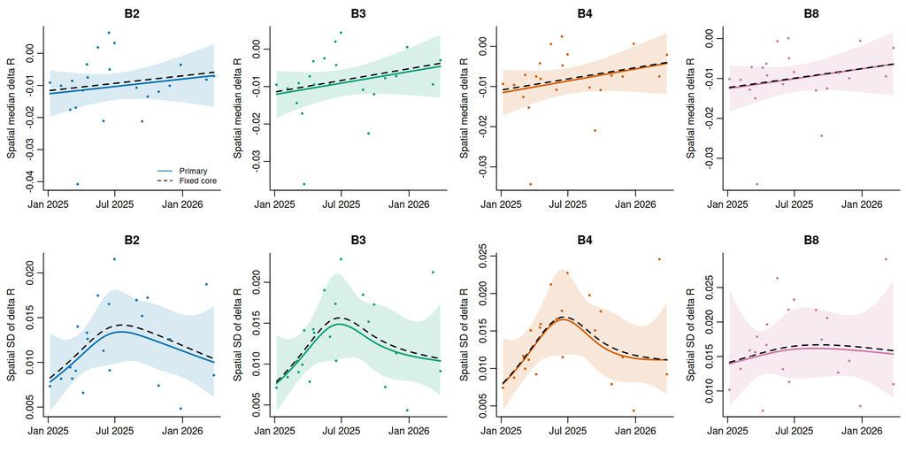

Primary curves with approximate pointwise model intervals (shading) and fixed complete-date core curves (dashed). Panels have separate vertical scales to show uncertainty. Bands assume independent Gaussian errors on the fitted scale and are illustrative; they are not simultaneous or predictive intervals.

Fitted 27 March 2026 versus 6 January 2025 contrasts: additive change for spatial medians; ratio for typical spatial SD. Approximate 95% working-model intervals; all median intervals include 0 and all SD-ratio intervals include 1. This is not evidence of no change.

| band | statistic | estimate | lower | upper |
| --- | --- | --- | --- | --- |
| B2 | median_delta | 0.00564 | -0.00917 | 0.02044 |
| B2 | sd_delta | 1.28024 | 0.64932 | 2.52419 |
| B3 | median_delta | 0.00745 | -0.00530 | 0.02020 |
| B3 | sd_delta | 1.36072 | 0.61430 | 3.01411 |
| B4 | median_delta | 0.00725 | -0.00435 | 0.01886 |
| B4 | sd_delta | 1.40150 | 0.62037 | 3.16618 |
| B8 | median_delta | 0.00610 | -0.00586 | 0.01805 |
| B8 | sd_delta | 1.10036 | 0.60617 | 1.99744 |

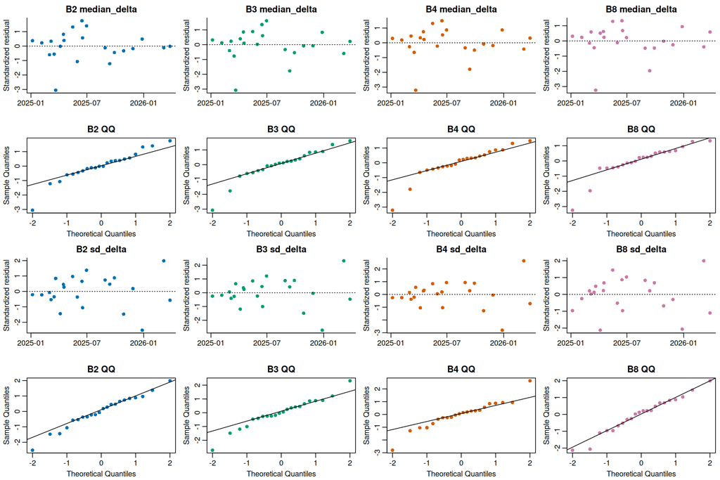

Standardized primary residuals against acquisition date and normal quantiles. Median residuals have a negative tail; log-SD residuals show alternating acquisition-level variation.

## 0.9 Scientific interpretation

The correction methods disagree systematically on most observed dates, and the size and spatial spread of that disagreement vary. Similar fixed-core curves suggest that a changing set of observed pixels does not alone explain the broad patterns. The study contains no independent surface-reflectance reference, so neither the negative sign nor reduced spatial SD identifies a more accurate correction. Atmospheric conditions, adjacency, tide, substrate visibility, land cover, sensor response and masking are plausible contributors, not tested mechanisms. The short and uneven series cannot establish recurrent seasonality, a long-term trend, or ecological change.

## 0.10 Reproducibility and validation

The executable statistical entry point is `scripts/ctr56_run.py`, which runs `scripts/ctr56_models.R` through the repository environment and the guarded figure-output helper. `scripts/ctr56_validate.py` independently recomputes date statistics from preserved difference rasters. `scripts/ctr56_check_outputs.R` checks saved models, tables, transformations and contrasts. All statistical writes are confined to this investigation; original data, upstream rasters and the final manuscript are preserved. The worktree shares the existing repository Python and R libraries; no lockfile or package change is part of this delivery.

The independent implementation audit checks all 528 table keys, positive finite SDs, counts and coverage formulas. It verifies the SHA-256 hashes of 24 paired-date rasters and four complete-core masks against the predecessor output manifest, then recomputes full-resolution medians and sample SDs for six dates spanning first acquisition, the negative outlier, minimum coverage, December, and both missing-flag acquisitions. All 48 primary/core summary rows match within 10⁻¹², including exact valid counts. This is an independent calculation by the analysis author, **not independent scientific review**. Raw-source validation from CTR-55 is reused, not claimed as rerun here.

The archive contains all statistical scripts, input date table, predictions, fitted models, diagnostics, 176 leave-one-date-out results, spatial-domain and quality sensitivities, source hash evidence and exact output hashes. It does not duplicate raw data or the raster archive. Main figure: 3096 × 2232 PNG at 360 dpi and vector PDF. HTML reports are self-contained and rendered with the investigation configuration. Figure review confirms both panel order and complete data ranges without clipping.

From this task worktree, using the canonical repository environment (set `CTR56_ENV_ROOT` to an equivalent restored project if relocated):

```bash
export CTR56_ENV_ROOT=/mnt/PaperClip_Projects/projects/banc-darguin-atmospheric-correction-2026
.venv/bin/python analysis/CTR-54_paired-reflectance-differences/scripts/ctr56_validate.py
.venv/bin/python analysis/CTR-54_paired-reflectance-differences/scripts/ctr56_run.py
"$CTR56_ENV_ROOT/scripts/project-env.sh" Rscript analysis/CTR-54_paired-reflectance-differences/scripts/ctr56_check_outputs.R analysis/CTR-54_paired-reflectance-differences
RENV_PATHS_LIBRARY="$CTR56_ENV_ROOT/renv/library" ./scripts/render-analysis.sh analysis/CTR-54_paired-reflectance-differences
```

Set `CTR56_PRODUCTS` to the preserved upstream investigation directory if the raster products are elsewhere. See `CTR56_HANDOFF.md` for the exact statistical commit, durable access and manifest hash. Default seed: 56054; no MCMC is used. The model warning log is retained, including an empty log when there are no warnings.

## 0.11 Internal review and approval status

Author computation and figure checks: completed, with distributional/dependence limitations explicitly retained. Independent scientific review: pending in the existing downstream CTR-59 workflow. PI scientific approval: pending; no authenticated decision bound to this statistical revision has been received. No manuscript integration, merge or publication is authorized by this report or its task metadata.

# 1 Preserved geospatial analysis (CTR-55)

## 1.1 Take-home message

ACOLITE surface reflectance is typically lower than Sen2Cor on the supplied T28QCH footprint across the 22 paired Sentinel-2 acquisitions. The maps and tables quantify disagreement between ACOLITE and Sen2Cor; they do not identify the more accurate correction or establish ecological change. Interpret temporal patterns alongside spatial coverage and quality information.

## 1.2 Meaningful results

The comparison retains all valid land, intertidal and water pixels in the supplied 742.8162 km² rectangular crop. ACOLITE dates 15 February and 13 October 2025 have no same-tile Sen2Cor counterpart. All selected pairs have matching sensor, datatake, orbit, tile and tile sensing time. Reflectance grids align exactly.

[output not shown]

These map-distribution summaries weight each eligible pixel once. The median of temporal medians is distinct from a pooled pixel/date median or the median of per-date spatial medians.

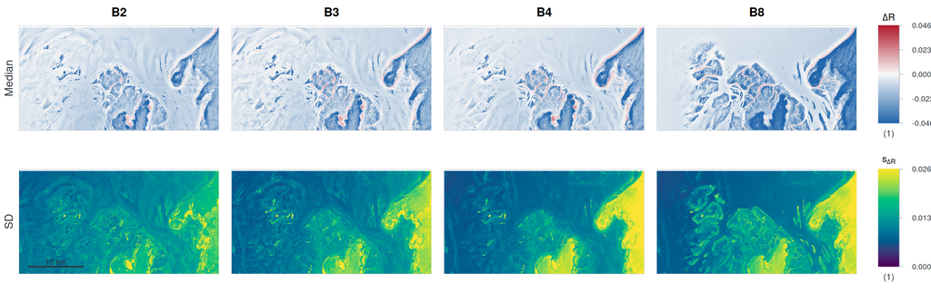

Paired reflectance differences

Temporal median (top) and sample SD (bottom) of paired surface-reflectance differences, ACOLITE − Sen2Cor, for B2, B3, B4 and B8 across 22 acquisitions (6 January 2025–27 March 2026). The full supplied T28QCH comparison crop is retained at 10 m in UTM zone 28N; no marine-only mask is added. Blank cells lack the observations required for the statistic (median n≥1; SD n≥2). Median limits are shared at ±0.04644; SD limits are shared at 0–0.02584, in dimensionless reflectance units. Display limits use pooled 98th-percentile scaling; values outside them are saturated for display only. Band-specific full-resolution clipping fractions appear below. A regular every-third-cell sample is used only to draw the maps. Missing ACOLITE flags on the two March 2026 dates and unequal per-pixel temporal coverage limit comparability; the figure does not establish correction accuracy.

### 1.2.1 Spatial summaries within each acquisition

| Band | Smallest date median ΔR | Largest date median ΔR | Primary grid coverage range | Dates with positive spatial median | Dates with defined median |
| --- | --- | --- | --- | --- | --- |
| B2 | -0.04078 | 0.00645 | 72.0%–98.3% | 3 | 22 |
| B3 | -0.03608 | 0.00441 | 72.0%–98.3% | 3 | 22 |
| B4 | -0.03431 | 0.00247 | 72.0%–98.3% | 3 | 22 |
| B8 | -0.03648 | 0.00009 | 72.0%–98.3% | 1 | 22 |

Each date/band has its own spatial median, sample SD and valid count in `tables/date_band_summary.csv`. Date gaps are unequal. Spatial SD is variation across retained pixels, not uncertainty of a mean or correction accuracy.

## 1.3 Issues and limitations

The original ACOLITE crop and its earlier polygon clipping constrain geographic scope; full Sentinel-2 tile coverage cannot be inferred from this crop. The two March 2026 ACOLITE deliveries lack flag layers. Their quality filtering therefore relies on Sen2Cor SCL and finite paired observations. SCL and ACOLITE flags have no independent validation here. Cloud remnants, aerosols, adjacency, glint, tide, bottom visibility, phenology, sensor differences and changing spatial sampling can all affect observed differences. Negative reflectance is retained when otherwise valid.

No field observations or ground-truth accuracy assessment enter this investigation. Cross-correction agreement is not evidence that either correction is accurate. No causal/ecological trend is inferred. Small temporal counts must be read alongside the count rasters.

## 1.4 Implications and next steps

Use the primary summaries for descriptive comparison and the sensitivity tables to assess dependence on quality and coverage. Statistical modelling should account for spatial/temporal dependence, sensor differences and unequal date gaps. The supplied spatial SD must not be treated as an independent measurement-error estimate. Independent review and a separate authenticated PI decision are required before findings can support the manuscript.

## 1.5 Question, data and methods

How do paired ACOLITE and Sen2Cor surface reflectances differ for B2/B3/B4/B8 in the available Sentinel-2 observations? ΔR = ACOLITE − Sen2Cor, dimensionless. B8A is excluded.

The inventory contains 24 ACOLITE date directories, 46 Sen2Cor ZIP products and two loose SAFE products. Twenty-two T28QCH acquisitions are paired across Sentinel-2A/B/C, 6 January 2025–27 March 2026. Unpaired products and reasons remain in `tables/acquisition_inventory.csv`. Candidate QCG tiles are not duplicated or substituted for CH. Sensor-specific ACOLITE band parameters and actual wavelengths are recorded in `tables/band_mapping.csv`.

Reference grid: EPSG:32628; 3763 × 1974 cells; 10 m; E=334050–371680 m; N=2190240–2209980 m. Sen2Cor reflectance is cropped at exact integer pixel offsets without interpolation. SCL uses nearest-neighbour transfer from 20 to 10 m. No additional ecological mask is imposed.

ACOLITE Float32 `rhos` is already dimensionless surface reflectance (scale 1, offset 0). Sen2Cor is decoded with each product’s XML as `(DN + BOA_ADD_OFFSET) / BOA_QUANTIFICATION_VALUE`; selected offsets are −1000 and quantification is 10000. DN=0, saturated DN, nonfinite ACOLITE observations and the exact default netCDF Float32 fill value are excluded. The supplied ACOLITE deliveries contain that finite sentinel despite their GeoTIFF NoData=NaN metadata; all 88 input band rasters are audited in `encoded_fill_audit.csv`. The audit identifies 118,596 fill cells per raster (1.60% of the rectangle). No arbitrary reflectance upper bound is applied; valid negative values are preserved.

Primary joint QA retains SCL 4/5/6 and rejects available ACOLITE cirrus, out-of-scene and DEM-shadow bits. Non-water SWIR and negative-reflectance flags are retained. Bright-pixel high-TOA flags are a separate sensitivity because they can remove valid land. Files without ACOLITE flags are identified explicitly. Full methods, assumptions and documentation are in `METHODS.md`.

Temporal median uses n≥1 and sample SD uses n≥2 with denominator n−1. Per-date spatial SD also uses n−1. Processing uses 64-row chunks, Float64 computation and disk-backed Float32 differences on local SSD. All reported statistics use full-resolution values; only drawing uses a regular sample. Raw files are read without alteration.

## 1.6 Coverage and mask sensitivity

The complete-date core retains only pixels valid on all 22 dates. The 80% core retains pixels valid on ≥18 dates. The common-footprint core requires finite paired observations in every band/date before quality masking. These conditional cores test coverage effects but can favour consistently clear locations. Additional masks include SCL 7 or exclude high-TOA flags. All domains and empty cases are retained in the downstream table.

| Band | Sensitivity domain | Median across dates of change in spatial median ΔR | Min valid pixels/date | Max valid pixels/date | Comparable dates |
| --- | --- | --- | --- | --- | --- |
| B2 | include_SCL7 | 0.00001 | 5364437 | 7305770 | 22 |
| B2 | exclude_high_TOA | 0.00088 | 4735434 | 7263590 | 22 |
| B2 | complete_dates | 0.00097 | 3541502 | 3541502 | 22 |
| B2 | coverage80 | -0.00000 | 5336432 | 7247257 | 22 |
| B2 | common_footprint | -0.00000 | 5346503 | 7299990 | 22 |
| B3 | include_SCL7 | 0.00000 | 5364446 | 7305781 | 22 |
| B3 | exclude_high_TOA | 0.00085 | 4735441 | 7263601 | 22 |
| B3 | complete_dates | 0.00070 | 3541623 | 3541623 | 22 |
| B3 | coverage80 | -0.00000 | 5336439 | 7247258 | 22 |
| B3 | common_footprint | -0.00000 | 5346503 | 7299990 | 22 |
| B4 | include_SCL7 | 0.00000 | 5364440 | 7305774 | 22 |
| B4 | exclude_high_TOA | 0.00078 | 4735435 | 7263594 | 22 |
| B4 | complete_dates | 0.00042 | 3541533 | 3541533 | 22 |
| B4 | coverage80 | 0.00000 | 5336433 | 7247254 | 22 |
| B4 | common_footprint | -0.00000 | 5346503 | 7299990 | 22 |
| B8 | include_SCL7 | -0.00000 | 5364444 | 7305635 | 22 |
| B8 | exclude_high_TOA | 0.00096 | 4735438 | 7263455 | 22 |
| B8 | complete_dates | 0.00028 | 3541100 | 3541100 | 22 |
| B8 | coverage80 | 0.00001 | 5336436 | 7247248 | 22 |
| B8 | common_footprint | -0.00000 | 5346503 | 7299990 | 22 |

A change in the spatial median can reflect changed spatial support; this table is descriptive, not an inferential test. Sensitivity domains overlap and are not independent samples. Primary footprint and negative-count diagnostics repeated in sensitivity rows are labelled explicitly in `TABLE_CONTRACT.md`.

## 1.7 Display clipping audit

| Band | Statistic | Display minimum | Display maximum | Clipped below | Clipped above |
| --- | --- | --- | --- | --- | --- |
| B2 | median | -0.04644 | 0.04644 | 0.89% | 0.00% |
| B3 | median | -0.04644 | 0.04644 | 1.04% | 0.00% |
| B4 | median | -0.04644 | 0.04644 | 1.54% | 0.00% |
| B8 | median | -0.04644 | 0.04644 | 4.55% | 0.00% |
| B2 | sd | 0.00000 | 0.02584 | 0.00% | 0.49% |
| B3 | sd | 0.00000 | 0.02584 | 0.00% | 0.94% |
| B4 | sd | 0.00000 | 0.02584 | 0.00% | 4.63% |
| B8 | sd | 0.00000 | 0.02584 | 0.00% | 1.86% |

The same limits apply to all four bands within a row. The full scientific rasters and tabulated minima/maxima remain unclipped. The exported PNG is 400 dpi (the HTML embeds a 200 dpi preview); the accompanying PDF preserves text and embeds map rasters.

## 1.8 Validation and reproducibility

Direct checks against original source pixels: 12; maximum absolute discrepancy 7.12e-10. Temporal raster spot checks: 96; maximum absolute discrepancy 1.86e-09. All 113 scientific raster outputs passed grid, CRS, datatype and NoData checks. Base R independently recomputes temporal statistics from the delivered sample values. Numerical check tables are retained; these checks are distinct from independent scientific review and thematic accuracy.

Inputs: `provenance/input_hashes.csv`; outputs: `provenance/output_hashes.csv`; exact revision, durable paths and execution commands: `HANDOFF.md` and `provenance/handoff.json`. Restore the repository lockfiles with the authorized project tools. Re-run the recorded `scripts/run.sh` sequence, including the source-fill audit, with `CTR54_SOURCE` and `CTR54_SCRATCH` set if needed. Figure and report stages use the recorded project Python/R and existing Quarto installation. No dependency change was required. Detailed software versions and lockfile hashes are in `provenance/environment.json`.

## 1.9 Internal review and approval status

Independent scientific review pending. PI scientific approval pending. Manuscript integration, merge and publication are not authorized.

## 1.10 Documentation

- [Copernicus Sentinel-2 product organization and reflectance decoding](https://sentiwiki.copernicus.eu/web/s2-products).
- [Copernicus Sentinel-2 processing and scene classification](https://sentiwiki.copernicus.eu/web/s2-processing).
- [Official ACOLITE project and processing documentation](https://github.com/acolite/acolite).
- [Official ACOLITE flag code](https://github.com/acolite/acolite/blob/main/acolite/acolite/acolite_flags.py). The source metadata record flag exponents; the original processor commit is not recoverable from the timestamp-style version string.